# Lecture 07

## 5.1.0 Using DataCamp to help with your coding

The proliferation of the GPT toolkit means that you’ll find LLMs being specifically trained on many different disciplines. Programming and data science tools are plentiful in that respect. Since you already have access to DataCamp, you’ll find that it also provides a workspace for you to experiment and improve your code. You’ll find the [DataLab](https://www.datacamp.com/datalab/) in your own account and ready to be accessed.

### 5.1.1 Upload data

We’ll begin by uploading the same data we’ve been working with today into a new workbook. In DataLab menu, you can select `Environment > Language > R 4.4`.

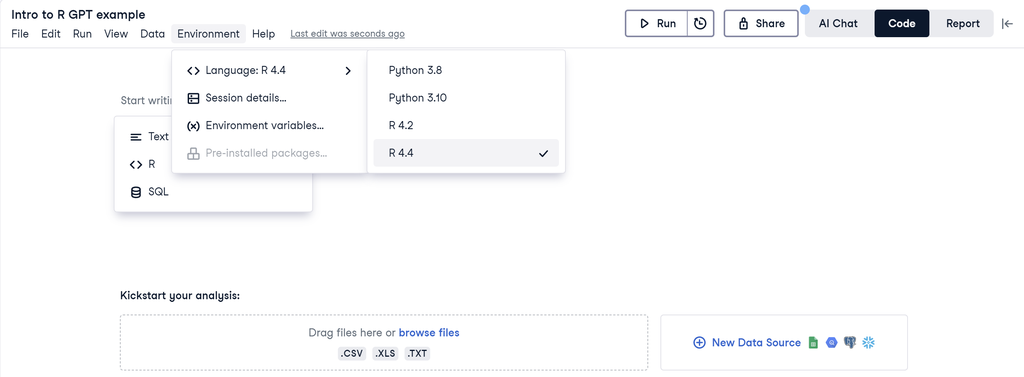

From there you can add data to your workbook in one of 2 ways:

1. Go to `Data > Show data sources` and from the sidebar, be sure to select the `Files` tab and use the `+ Add` button. This will allow you to add your data to the workbook. For this task you’ll want to download this week’s `embryo_data_long_merged.csv` file from RStudio Server to your desktop first!
2. You can use the `Kickstart your analysis` interface to drag and drop a file into your workbook.

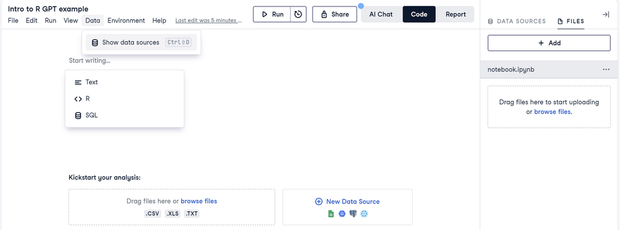

### 5.1.2 Insert your first code cell

You can insert your first code cell by clicking on the `Start writing...` section with `<R>` to create a code cell (much like in our notebooks).

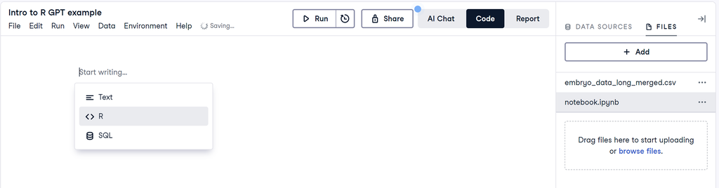

### 5.1.3 Import your libraries and dataset

Next we’ll want to load our libraries and import the data into R. You can copy and paste the following code into your code cell. Nothing we haven’t done before. Afterwards, hit the Run button on the right side of the code cell.

```r
# Install the ggbeeswarm package if it is not already installed
if (!requireNamespace("ggbeeswarm", quietly = TRUE)) {
  install.packages("ggbeeswarm")
}

# Load the necessary libraries
library(tidyverse)
library(ggbeeswarm)

# Read the CSV file into a dataframe
embryo.df <- read_csv("embryo_data_long_merged.csv")
```

### 5.1.4 Generate a faceted plot from our own data

We’ll start by making a simple faceted plot - again much like what we’ve done before but THEN we’ll use the power of AI to help us improve it! Insert a new code cell and run it on DataLab!

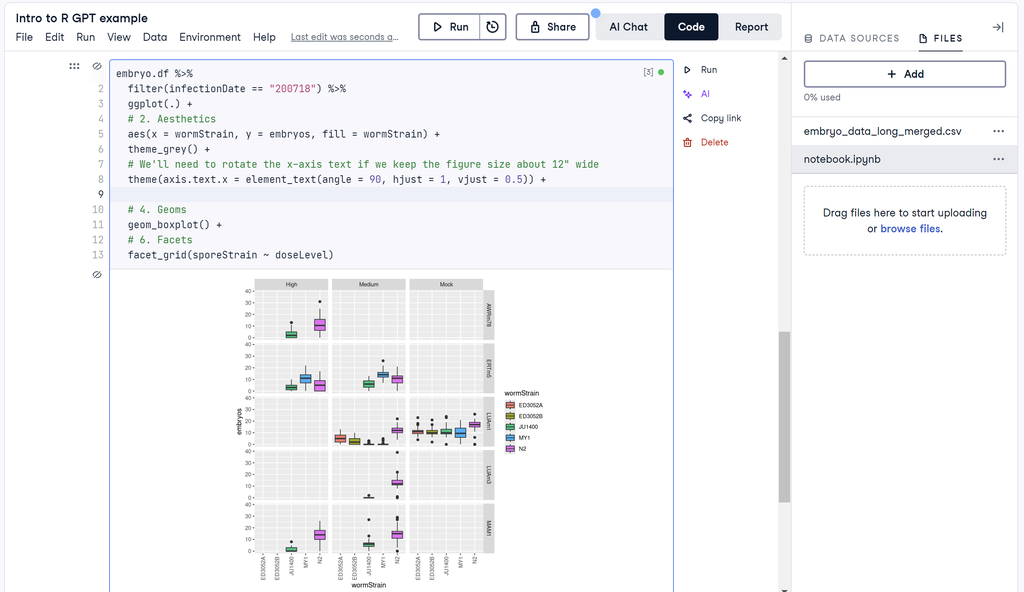

```r
embryo.df %>%
  filter(infectionDate == "200718") %>%
  ggplot(.) +
  # 2. Aesthetics
  aes(x = wormStrain, y = embryos, fill = wormStrain) +
  theme_grey() +
  # We'll need to rotate the x-axis text if we keep the figure size about 12" wide
  theme(axis.text.x = element_text(angle = 90, hjust = 1, vjust = 0.5)) +

  # 4. Geoms
  geom_boxplot() +
  # 6. Facets
  facet_grid(sporeStrain ~ doseLevel)
```

## 5.2.0 Use the AI function to help improve your code!

Let’s walk through the following prompts. Each time we enter a prompt, you’ll see the updated code and will need `Accept` it before running it in order to see the updated output. In most of the following sections, you can use the section title as our AI prompt.

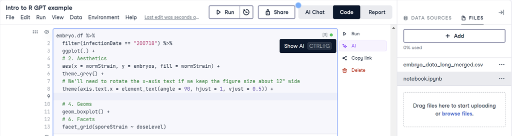

### 5.2.1 Make the output larger

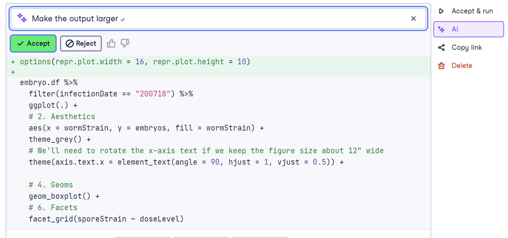

Note that while we are using the `repr` package, that is more for Jupyter Notebooks rather than R Markdown!

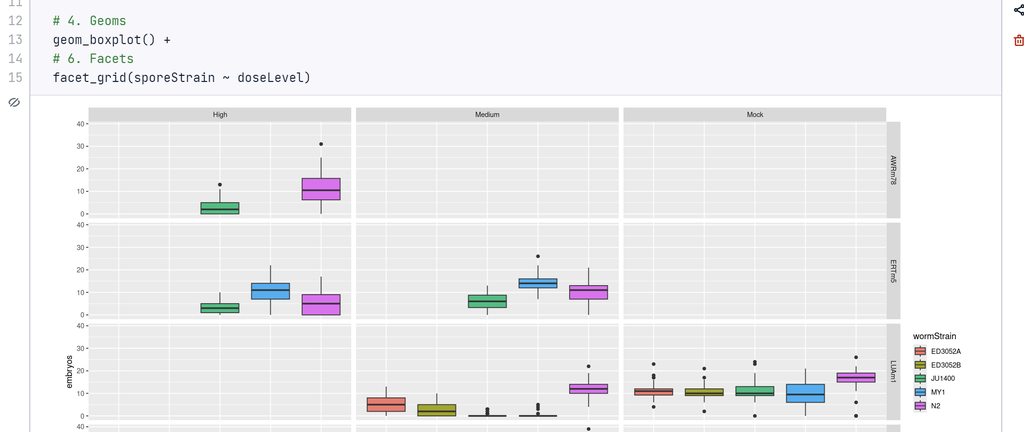

### 5.2.2 Make the plot colour-blind friendly

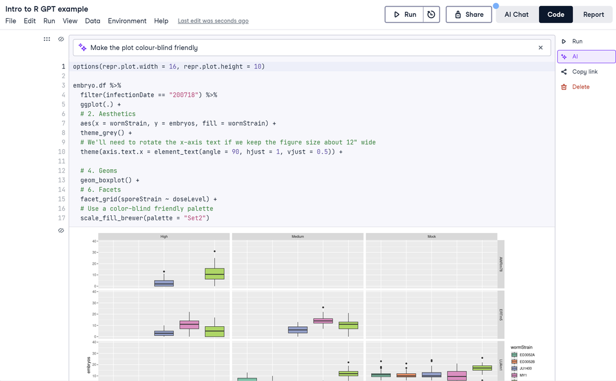

### 5.2.4 Be specific with your prompts!

Let’s try “Filter sporeStrain by removing LUAm3 and MAM1”. You can also remove the erroneous filter line from the result.

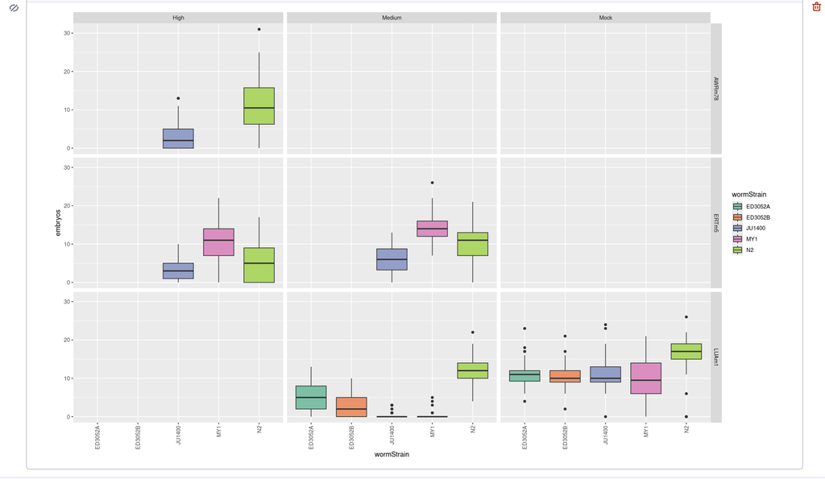

### 5.2.5 Convert to a violin plot with datapoints as a beeswarm with 50% transparency

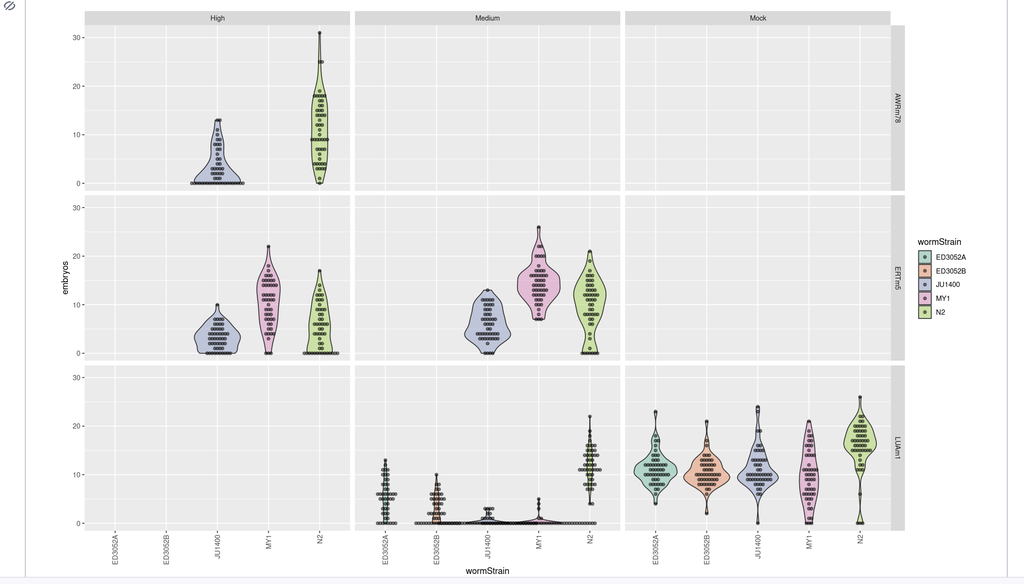

### 5.2.6 Replace beeswarm with a quasirandom plotting

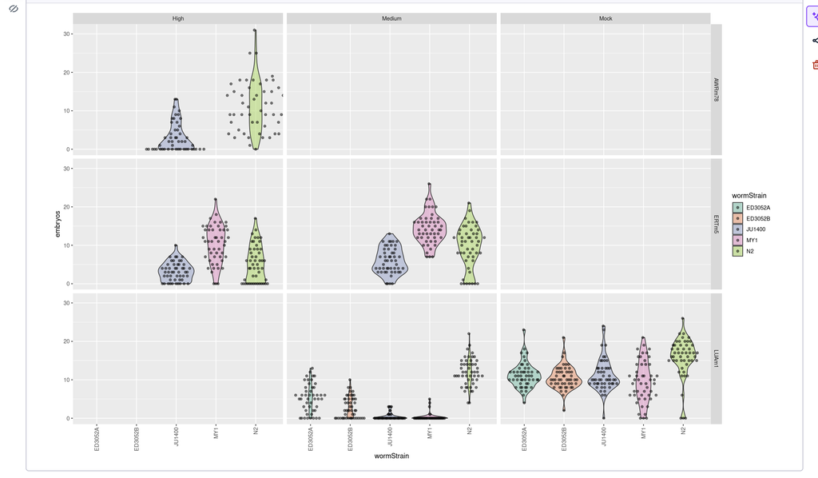

### 5.2.7 Decrease the quasirandom width to match the violin width

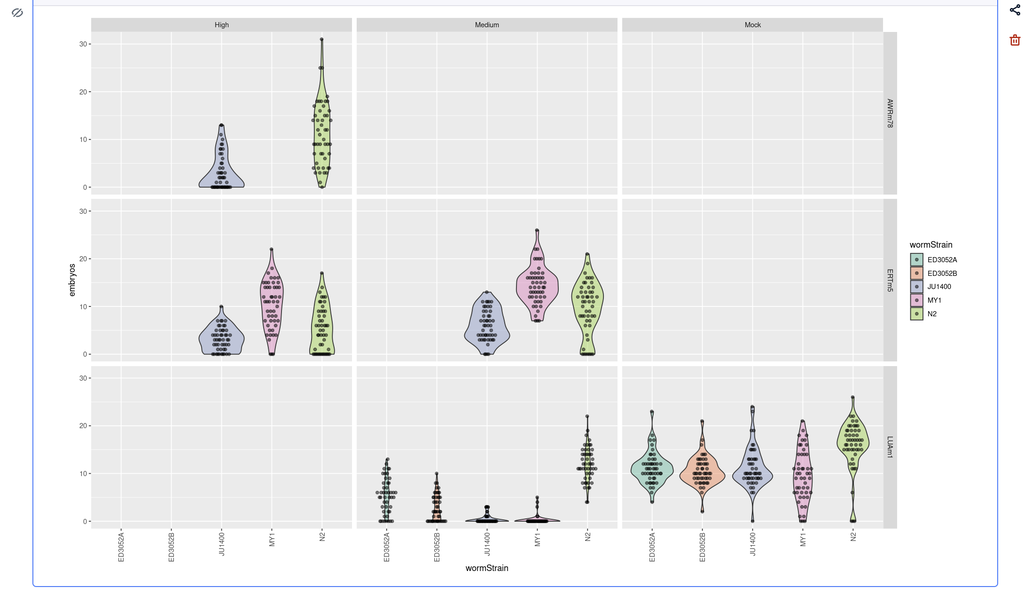

### 5.2.8 Make the facet titles bold and increase their font size

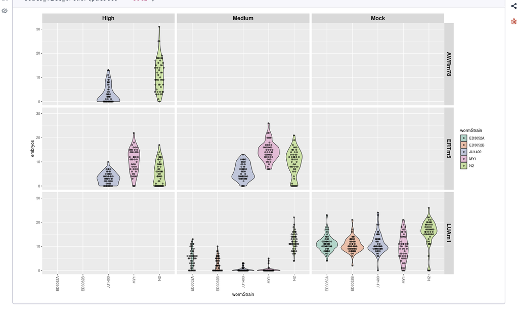

### 5.2.9 Make facet titles for only the rows in bold italic font

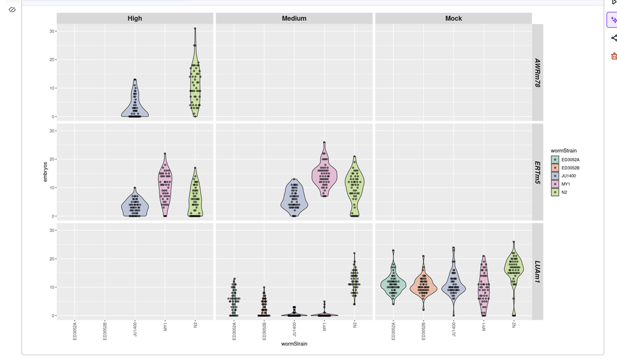

And using only our prompts, we have created our figure and can save the code elsewhere like below!

```r
options(repr.plot.width = 16, repr.plot.height = 10)

embryo.df %>%
  filter(infectionDate == "200718",
         !sporeStrain %in% c("LUAm3", "MAM1")) %>%
  ggplot(.) +
  # 2. Aesthetics
  aes(x = wormStrain, y = embryos, fill = wormStrain) +
  theme_grey() +
  # We'll need to rotate the x-axis text if we keep the figure size about 12" wide
  theme(axis.text.x = element_text(angle = 90, hjust = 1, vjust = 0.5),
        strip.text = element_text(face = "bold", size = 14),
        strip.text.y = element_text(face = "bold.italic"),
        strip.text.x = element_text(face = "bold")) +

  # 4. Geoms
  geom_violin(alpha = 0.5) +
  geom_quasirandom(alpha = 0.5, width = 0.2) +
  # 6. Facets
  facet_grid(sporeStrain ~ doseLevel) +
  # Use a color-blind friendly palette
  scale_fill_brewer(palette = "Set2")
```

# 6.0.0 There is always more to explore!

[figure not shown]

While this is the end for us, it’s not the end for you!

Let’s review our time together. Over the span of this course we’ve discussed

1. Basic data types, objects and classes in R.
2. Data manipulation with the `dplyr` package.
3. Principles of tidy data using the `tidyverse` package.
4. The grammar of graphics with the `ggplot2` package.
5. Regular expressions and string manipulation with `stringr`.
6. Regression and data analysis with general linear methods.
7. Control flow through looping and functions.

You now have the tools to accomplish quite a few tasks and the foundation to grow your skills as needed. **Let’s run a final function together to celebrate!**

```r
# Time to run our final function together
goodbye.class()
```

```
## [1] "Thank you for coming to lectures! I'm looking forward to seeing your final projects!"
```

## 6.1.0 Post-course survey

There is no post-lecture assessment this week. Your DataCamp accounts will continue to remain active for another ~4 months during which time you can choose to explore the site’s different courses. Please take advantage of this opportunity to keep growing your R skills!

However, we have created a post-course survey you can fill out anonymously. You can use this survey as an opportunity to tell us about your experience and help shape the future offerings of this series. Please take 5-10 minutes to fill out the survey. We really appreciate your feedback!

[Anonymous Google Survey found here](https://forms.gle/MtRc4QS3Qc4q5qGc6)

## 6.2.0 Submit your completed skeleton notebook (2% of final grade)

At the end of this lecture a Quercus assignment portal will be available to submit a **RMD** version of your completed skeletons from today (including the comprehension question answers!). These will be due one week later, before the next lecture. Each lecture skeleton is worth 2% of your final grade but a **bonus 0.5%** will also be awarded for submissions made within 24 hours from the end of lecture (ie 1600 hours the following day). To save your notebook:

1. From the RStudio Notebook in the lower right pane (**Files** tab), select the skeleton file checkbox (left-hand side of the file name)
2. Under the **More** button drop down, select the **Export** button and save to your hard drive.
3. Upload your RMD file to the Quercus skeleton portal.

[figure not shown]

## 6.3.0 Final assignment guidelines (50% of final grade)

Your final project will be due two weeks after this lecture at 2359 hours on Tuesday October 28th. Please submit your final assignment as a **single compressed file** which will include:

1. Your R Markdown Notebook final project
2. A **PDF version** of the notebook with all output from the code cell. This will be used for markup and comments that I can return to you about your projects. From the RStudio server, you can “knit” your project to HTML and then print as a PDF.
3. Any associated data needed to run your project. When you create your compressed file for submission, you can preserve the folder structure by exporting the entire folder with the needed files. Selecting the folder for export will automatically compress it as a `.zip` file.

Please refer to the marking rubric found in this course’s root directory on the datatools RStudio for additional instructions.

You can also build your R Markdown Notebooks on the UofT JupyterHub and save/download the files to your personal computer for compressing before submitting on Quercus.

Any additional questions can be emailed to me or the TAs or posted to the Discussion section of Quercus. Best of luck!

[figure not shown]

Don’t forget to submit your term project!

## 6.4.0 Acknowledgements

**Revision 1.0.0**: materials prepared in R Markdown by Oscar Montoya, M.Sc. *Bioinformatician, Education and Outreach, CAGEF.*

**Revision 1.1.0**: edited and prepared for **CSB1020H F LEC0142**, 09-2021 by Calvin Mok, Ph.D. *Bioinformatician, Education and Outreach, CAGEF.*

**Revision 1.1.1**: edited and prepared for **CSB1020H F LEC0142**, 09-2022 by Calvin Mok, Ph.D. *Bioinformatician, Education and Outreach, CAGEF.*

**Revision 1.1.2**: edited and prepared for **CSB1020H F LEC0142**, 09-2023 by Calvin Mok, Ph.D. *Bioinformatician, Education and Outreach, CAGEF.*

**Revision 1.2.0**: edited and prepared for **CSB1020H F LEC0142**, 09-2024 by Calvin Mok, Ph.D. *Bioinformatician, Education and Outreach, CAGEF.*

**Revision 1.2.1**: edited and prepared for **CSB1020H F LEC0142**, 09-2025 by Calvin Mok, Ph.D. *Bioinformatician, Education and Outreach, CAGEF.*

## 6.5.0 Your DataCamp academic subscription

This class is supported by DataCamp, the most intuitive learning platform for data science and analytics. Learn any time, anywhere and become an expert in R, Python, SQL, and more. DataCamp’s learn-by-doing methodology combines short expert videos and hands-on-the-keyboard exercises to help learners retain knowledge. DataCamp offers 350+ courses by expert instructors on topics such as importing data, data visualization, and machine learning. They?re constantly expanding their curriculum to keep up with the latest technology trends and to provide the best learning experience for all skill levels. Join over 6 million learners around the world and close your skills gap.

Your DataCamp academic subscription grants you free access to the DataCamp’s catalog for 6 months from the beginning of this course. You are free to look for additional tutorials and courses to help grow your skills for your data science journey. Learn more (literally!) at [DataCamp.com](https://learn.datacamp.com/).

[figure not shown]

## 6.6.0 Resources

- A primer on flow control https://adv-r.hadley.nz/control-flow.html
- Conditional statements and for loops https://resbaz.github.io/2014-r-materials/lessons/30-control-flow/
- More on control structures https://bookdown.org/rdpeng/rprogdatascience/control-structures.html

[figure not shown]